# HW02

Donna Dalrymple

January 29, 2017

```r
library(knitr)
library(readxl)
library(tidyverse)
```

### Exploring Unemployment Rates

Using data from The Bureau of Labor Statistics provides [data](https://www.bls.gov/lau/rdscnp16.htm) on the annual averages of the “employment status of the civilian noninstitutional population” from 1976 to 2015.

It also provides the [historical U.S. national annual unemployment rate](https://data.bls.gov/timeseries/LNU04000000?years_option=all_years&periods_option=specific_periods&periods=Annual+Data).

```r
  bls <- read_excel("staadata.xlsx")
  bls <- bls[8:nrow(bls),c(2,3,10)]
  colnames(bls)<- c("State","Year", "Rate")
  bls$Rate <- as.numeric(bls$Rate)
  unemp <- read_excel("SeriesReport-20170125193553_b114a0.xlsx", skip=10, col_names=TRUE)
```

### Is the current national unemployment rate going up, down or holding steady?

The graph of the national unemployment rate shows the trend is heading upwards from just under 5% in 1947 to almost 7% in 2016.

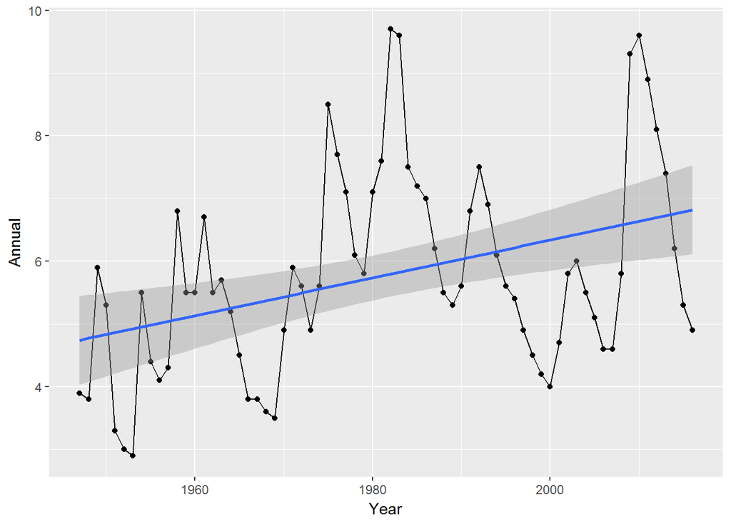

```r
unemp <- mutate(unemp, Year=as.Date(sprintf("%d-01-01", as.integer(Year))))

ggplot(unemp, aes(Year, Annual)) +
  geom_line(aes(group=1)) +
  geom_point() +
  stat_smooth(method = lm)
```

```r
  scale_x_date(date_breaks="10 years", date_labels="%Y")
```

```
## <ScaleContinuousDate>
##  Range:
##  Limits:    0 --    1
```

### What was the mean unemployment rate for New Jersey by complete decade?

For the decade 1976-1985, the mean NJ Unemployment rate was 7.71%. The following decade 1986-1995, NJ’s mean unemployment rate decreased to 5.79%.  
The mean NJ employment rate dropped further to 4.94% for the decade of 1996-2005. FOr the decade of 2006-2015, the rate jump up to 7.20% returning close to the levels of 1976-1985.

```r
lut <- c("1" = "1976-1985", "2" = "1986-1995", "3" ="1996-2005", "4" = "2006-2015" )

bls10 <- mutate(bls,Decade=as.character(ntile(Year,4)))
bls10$Decade <- lut[bls10$Decade]

NJbls10 <- filter(bls10, State == "New Jersey")%>%
    group_by(Decade)%>%
    summarise(mean(Rate))
NJbls10
```

```
## # A tibble: 4 × 2
##      Decade `mean(Rate)`
##       <chr>        <dbl>
## 1 1976-1985         7.71
## 2 1986-1995         5.79
## 3 1996-2005         4.94
## 4 2006-2015         7.20
```

### How does the mean unemployment rate for New Jersey by complete decade compare to the mean unemployment rate by complete decade for for Wyoming?

With the exception of the decade of 1986-1995, the mean unemloyment rate of Wyoming was lower than the unemployment rate of NJ

```r
WYbls10 <- filter(bls10, State == "Wyoming")%>%
  group_by(Decade)%>%
  summarise(mean(Rate))

NJWYbls10 <- filter(bls10, State == "New Jersey"|State == "Wyoming")%>%
  group_by(Decade, State)%>%
  summarise(Mean = mean(Rate))

spread(NJWYbls10, State, Mean)%>%
  mutate(Difference =  `New Jersey`- Wyoming )
```

```
## Source: local data frame [4 x 4]
## Groups: Decade [4]
##
##      Decade `New Jersey` Wyoming Difference
##       <chr>        <dbl>   <dbl>      <dbl>
## 1 1976-1985         7.71    4.87       2.84
## 2 1986-1995         5.79    6.07      -0.28
## 3 1996-2005         4.94    4.24       0.70
## 4 2006-2015         7.20    4.59       2.61
```

### Which state(s) — could be ties — have the lowest (most current) unemployment rate?

for 2015, North Dakota had the lowest unemployment rate of 2.7%

```r
  bls15 <- filter(bls, Year == "2015")
  bls15[order(bls15$Rate),] %>%
  head()
```

```
## # A tibble: 6 × 3
##           State  Year  Rate
##           <chr> <chr> <dbl>
## 1  North Dakota  2015   2.7
## 2      Nebraska  2015   3.0
## 3  South Dakota  2015   3.1
## 4 New Hampshire  2015   3.4
## 5          Utah  2015   3.5
## 6        Hawaii  2015   3.6
```

### Which states(s) — could be ties — had the lowest unemployment unemployment rate in 2008?

for 2008, South Dakota and Wyoming tied for the lowest unemployment rate with 3.1% each.

```r
  bls08 <- filter(bls, Year == "2008")
  bls08[order(bls08$Rate),] %>%
  head()
```

```
## # A tibble: 6 × 3
##          State  Year  Rate
##          <chr> <chr> <dbl>
## 1 South Dakota  2008   3.1
## 2      Wyoming  2008   3.1
## 3 North Dakota  2008   3.2
## 4     Nebraska  2008   3.3
## 5         Utah  2008   3.6
## 6     Oklahoma  2008   3.7
```